# FinalProject

THIS CODE LOADS ALL THE LIBRARIES WARNING: ALL THESE LIBRARIES MUST BE INSTALLED BEFORE LOADING THEM

```r
library (tidyverse)
library (knitr)
library (dplyr)
library (rpart)
library (partykit)
```

```r
library (maps)
library (readr)
library (rvest)
```

THIS CODE LOADS SOME OF THE DATA SETS

```r
path <- "https://raw.githubusercontent.com/ntaback/UofT_STA130/master/Fall2018/Finalproject/"

democracyindex2017 <- read_csv(paste0(path,"democracyindex2017.csv"))
education_cia2017 <- read_csv(paste0(path,"education_cia2017.csv"))
gdpppp_cia2017 <- read_csv(paste0(path,"gdpppp_cia2017.csv"))
lifeexpect_cia2017 <- read_csv(paste0(path,"lifeexpect_cia2017.csv"))
healthexpend_cia2017 <- read_csv(paste0(path,"healthexpend_cia2017.csv"))
internetusers_cia2017 <- read_csv(paste0(path,"internetusers_cia2017.csv"))
telephonelines_cia2017 <- read_csv(paste0(path,"telephonelines_cia2017.csv"))
population_cia2017 <- read_csv(paste0(path,"population_cia2017.csv"))
world_regions <- read_csv(paste0(path,"world_regions.csv"))
```

THIS CODE LOADS THE OPTIONAL DATA SETS

```r
get_CIAWFB_data <- function(table_url){
  library(rvest)
  dat <- xml2::read_html(table_url) %>% rvest::html_table()
  dat[[1]]
}
medianage_cia2017 <- get_CIAWFB_data("https://www.cia.gov/library/publications/resources/the-world-factbook/rankorder/2177rank.html")
```

Internet users world-wide geopgraphical area mapping

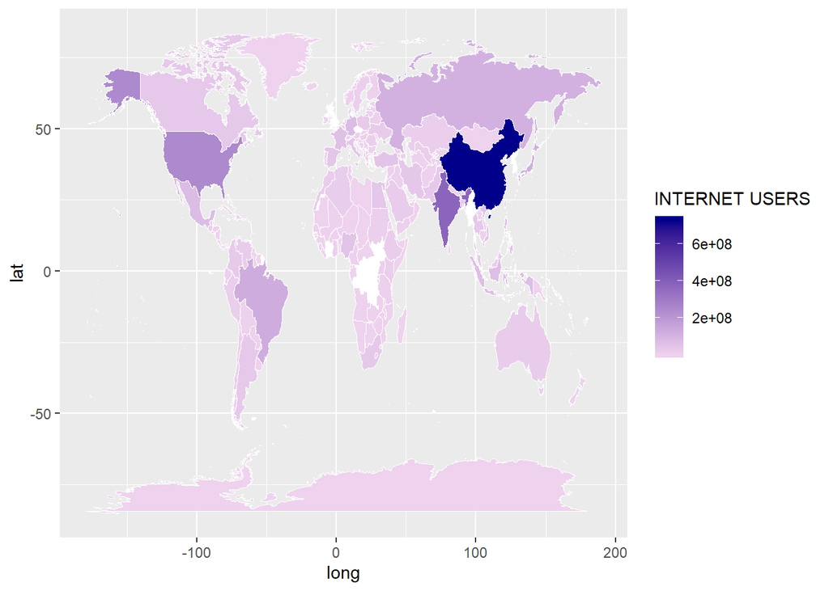

```r
world <- map_data("world")

#nternetusers_cia2017 <- read_csv("internetusers_cia2017.csv")

iu <- internetusers_cia2017 %>% rename(region = Country)

iu$region[4] <- "USA" # to match world map data

iu <- semi_join(iu, world, by = "region") #only keep countries according to world map data

# code below is modified from
# https://stackoverflow.com/questions/29614972/ggplot-us-state-map-colors-are-fine-polygons-jagged-r
gg <- ggplot()

gg <- gg + geom_map(
  data = world,
  map = world,
  aes(x = long, y = lat, map_id = region),
  fill = "#ffffff",
  color = "#ffffff",
  size = 0.20
  )
  gg <- gg + geom_map(
  data = iu,
  map = world,
  aes(fill = `INTERNET USERS`, map_id = region),
  color = "#ffffff",
  size = 0.15
  )

  gg <- gg + scale_fill_continuous(low = 'thistle2', high = 'darkblue',
  guide = 'colorbar')
  gg
```

CALCULATE THE PERCENTAGE OF PEOPLE WHO ARE INTERNET USERS

```r
internet_population <- inner_join(internetusers_cia2017, population_cia2017, by = "Country")
internet_population <- internet_population %>%
  mutate(percentage = round((`INTERNET USERS`/POPULATION)*100))
internet_population$Rank.y <- NULL
internet_population$`Date of Information.x` <- NULL
internet_population$`Date of Information.y` <- NULL
```

IS THERE A RELATIONSHIP BETWEEN GDP AND PERCENTAGE OF PEOPLE WHO USE INTERNET?

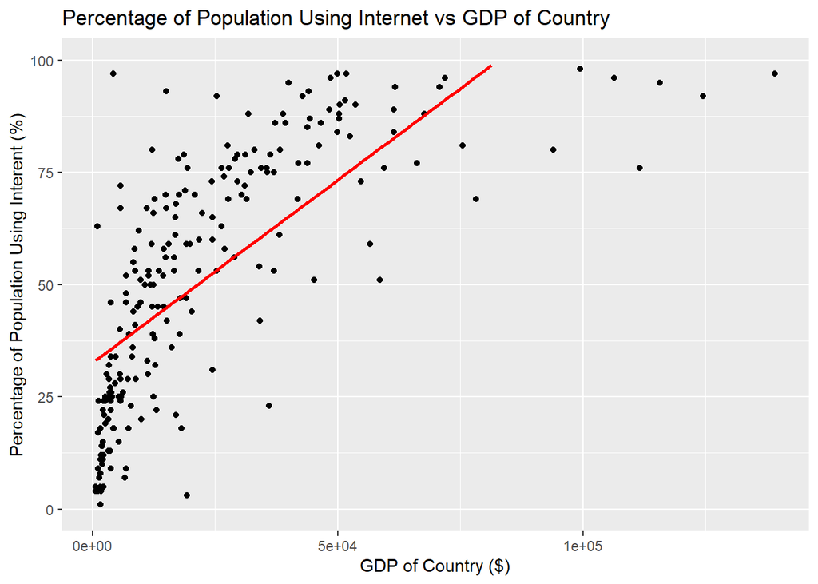

```r
gdp_internetuser <- inner_join(gdpppp_cia2017,internet_population, by = "Country")
gdp_internetuser$Rank.x<- NULL
gdp_internetuser$`Date of Information`<- NULL

gdp_internetuser <- gdp_internetuser %>%
  mutate (money = parse_number(`GDP - PER CAPITA (PPP)`))
gdp_internetuser$`GDP - PER CAPITA (PPP)`<- NULL

ggplot (data = gdp_internetuser, aes(x = money, y = percentage)) + geom_point() + stat_smooth(method = "lm", colour = "Red", se = FALSE) + ylim(0,100) + xlab("GDP of Country ($)") + ylab("Percentage of Population Using Interent (%)") + labs(title = "Percentage of Population Using Internet vs GDP of Country")
```

IS THERE A RELATIONSHIP BETWEEN MEDIAN AGE OF COUNTRY AND PERCENTAGE OF PEOPLE WHO USE INTERNET?

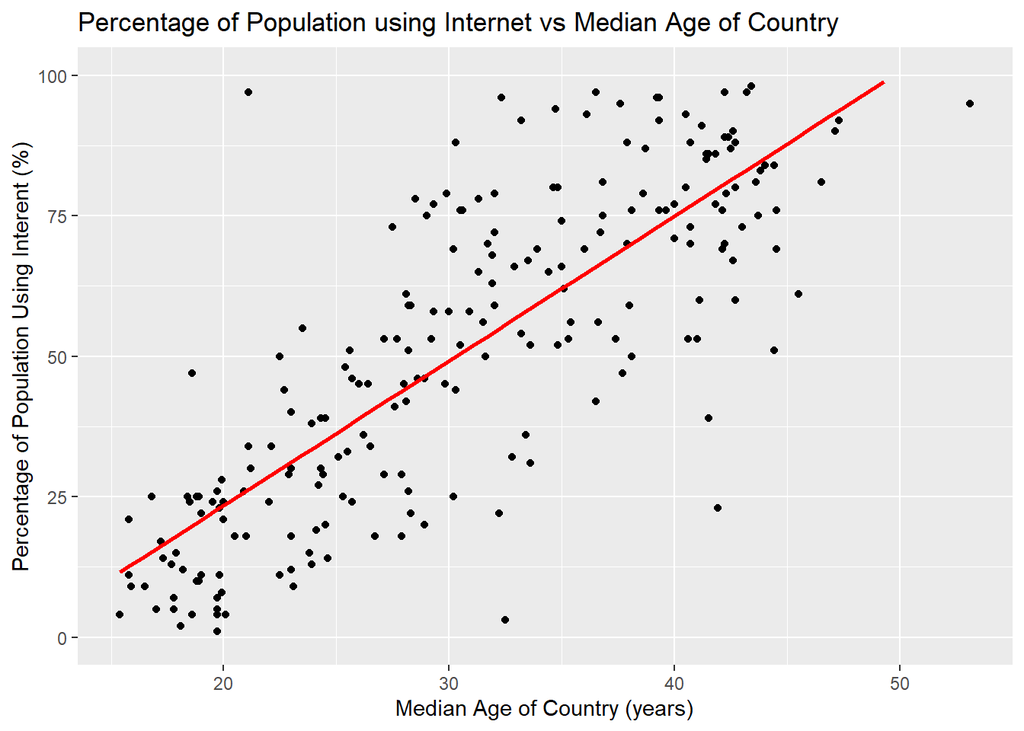

```r
medianage_percentage <- inner_join(medianage_cia2017,internet_population, by = "Country")
medianage_percentage$`Date of Information`<- NULL
medianage_percentage$Rank.x<- NULL

ggplot (data = medianage_percentage, aes(x = `MEDIAN AGE`, y = percentage)) + geom_point() + stat_smooth(method = "lm", colour = "Red", se = FALSE) + ylim(0,100) + xlab("Median Age of Country (years)") + ylab("Percentage of Population Using Interent (%)") + labs(title = "Percentage of Population using Internet vs Median Age of Country")
```

[figure not shown]

```r
education_health <- inner_join(education_cia2017, healthexpend_cia2017, by = "Country")

education_health$Rank.y <- NULL
education_health$`Date of Information.x` <- NULL
education_health$`Date of Information.y` <- NULL
education_health <- education_health %>%
  mutate(`Total expenditure` = `(% OF GDP).x` + `(% OF GDP).y`)
expenditure_percentage <- inner_join(education_health, internet_population, by = "Country")
expenditure_percentage$Rank.x.y <- NULL

ggplot(data = expenditure_percentage, aes(x = `(% OF GDP).x`, y = percentage)) + geom_point() + stat_smooth(method = "lm", colour = "Red", se = TRUE) + ylim(0,100) + xlab("Medical Expenditures") + ylab("Percentage of population using interent (%)") + labs(title = "Percentage of population using internet vs Medical Expenditures")
```

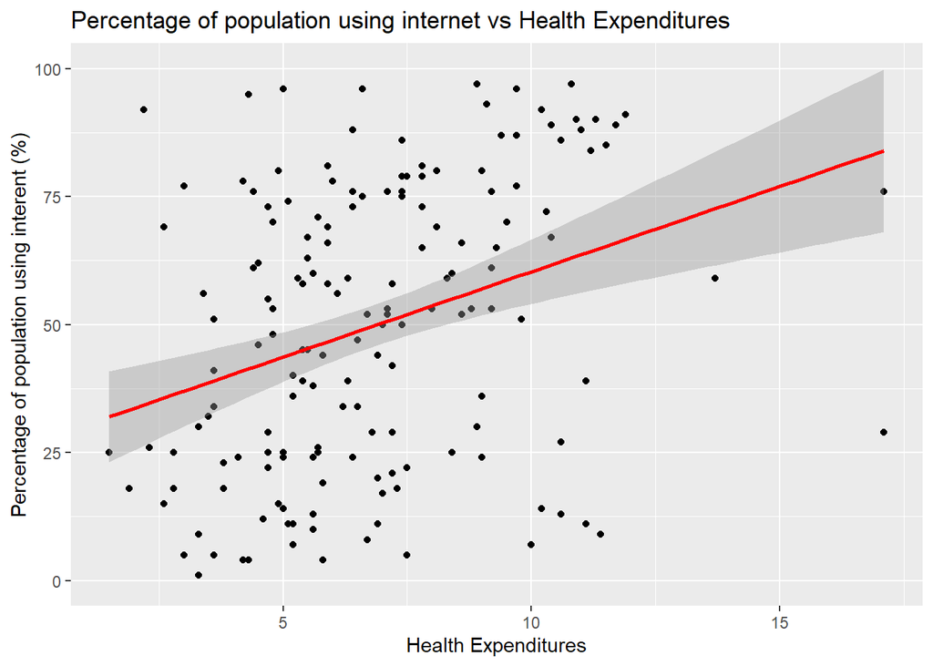

```r
ggplot(data = expenditure_percentage, aes(x = `(% OF GDP).y`, y = percentage)) + geom_point() + stat_smooth(method = "lm", colour = "Red", se = TRUE) + ylim(0,100) + xlab("Health Expenditures") + ylab("Percentage of population using interent (%)") + labs(title = "Percentage of population using internet vs Health Expenditures")
```

HEALTH SUBSETS

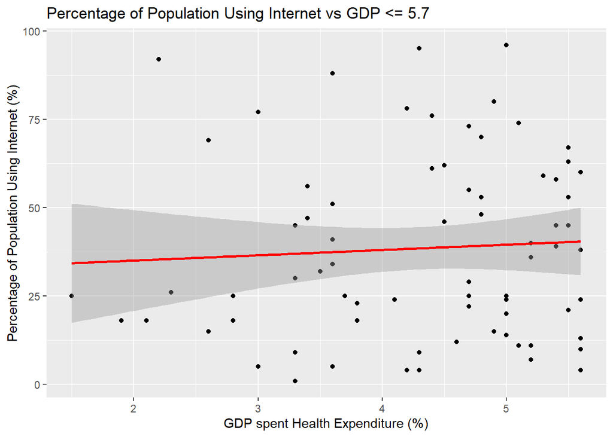

```r
health_percentage <- inner_join(healthexpend_cia2017, internet_population, by = "Country")

health_percentage <- health_percentage %>%
  mutate(group = ifelse(`(% OF GDP)` < 17.1/3, '1',ifelse(`(% OF GDP)` >= 17.1/3 & `(% OF GDP)` < (17.1*2)/3, '2','3')))

health_percentage <- health_percentage %>%
  group_by(group) %>%
  select (`(% OF GDP)`, Country, group, percentage)

health_gdp_1 <- health_percentage %>%
  filter(group == '1') %>%
  select (`(% OF GDP)`, group, percentage)

health_gdp_2 <- health_percentage %>%
  filter(group == '2') %>%
  select (`(% OF GDP)`, group, percentage)

health_gdp_3 <- health_percentage %>%
  filter(group == '3') %>%
  select (`(% OF GDP)`, group, percentage)


ggplot(data = health_gdp_1, aes(x = `(% OF GDP)`, y = percentage)) + geom_point() + stat_smooth(method = "lm", colour = "Red") + labs(x = "GDP spent Health Expenditure (%)", y = "Percentage of Population Using Internet (%)", title = "Percentage of Population Using Internet vs GDP <= 5.7")
```

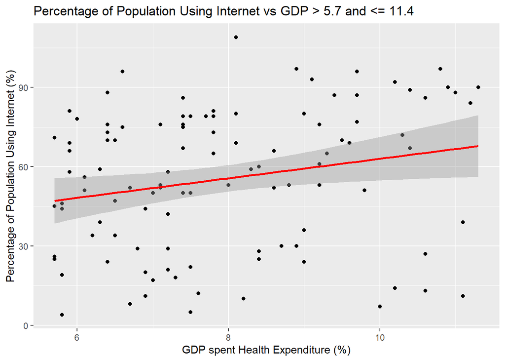

```r
ggplot(data = health_gdp_2, aes(x = `(% OF GDP)`, y = percentage)) + geom_point() + stat_smooth(method = "lm", colour = "Red")+ labs(x = "GDP spent Health Expenditure (%)", y = "Percentage of Population Using Internet (%)", title = "Percentage of Population Using Internet vs GDP > 5.7 and <= 11.4")
```

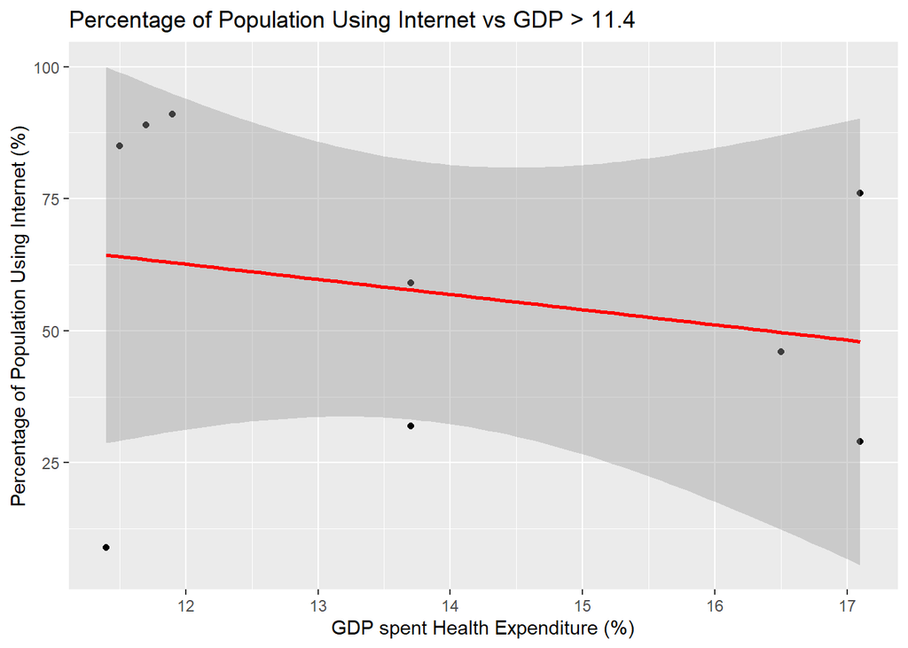

```r
ggplot(data = health_gdp_3, aes(x = `(% OF GDP)`, y = percentage)) + geom_point() + stat_smooth(method = "lm", colour = "Red")+ labs(x = "GDP spent Health Expenditure (%)", y = "Percentage of Population Using Internet (%)", title = "Percentage of Population Using Internet vs GDP > 11.4")
```

EDUCATION SUBSETS

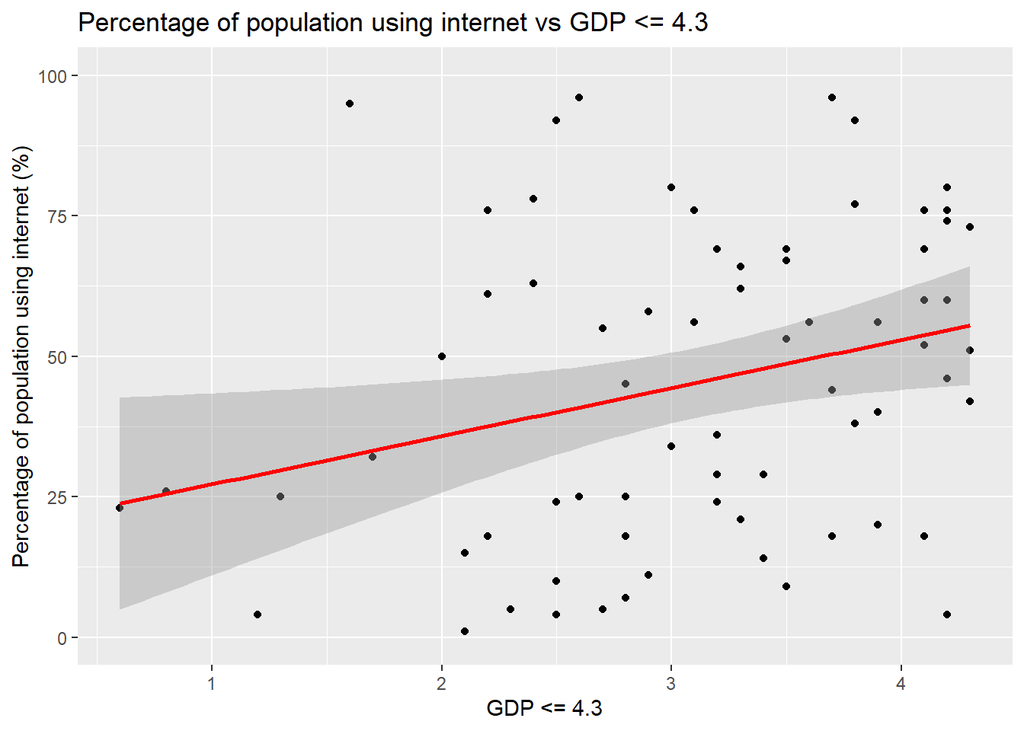

```r
expenditure_percentage <- expenditure_percentage %>%
  mutate(group = ifelse(`(% OF GDP).x` <= 4.3, '1',ifelse(`(% OF GDP).x` > 4.3 & `(% OF GDP).x` < 8.6, '2', '3')))

education_gdp_1 <- expenditure_percentage %>%
  filter(group == '1') %>%
  select (`(% OF GDP).x`, group, percentage)
ggplot(data = education_gdp_1, aes(x = `(% OF GDP).x`, y = percentage)) + geom_point() + stat_smooth(method = "lm", colour = "Red") + ylim(0,100) + xlab("GDP <= 4.3") + ylab("Percentage of population using internet (%)") + labs(title = "Percentage of population using internet vs GDP <= 4.3")
```

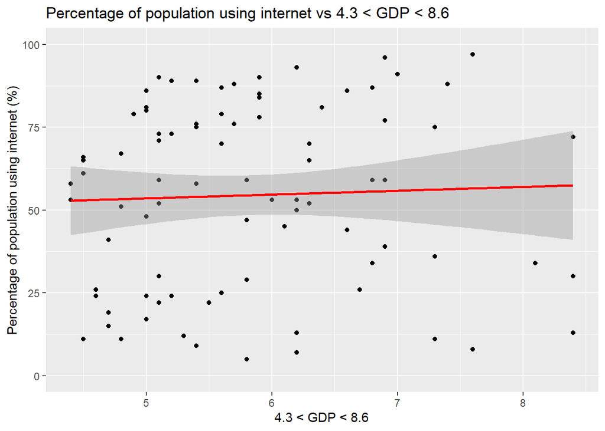

```r
education_gdp_2 <- expenditure_percentage %>%
  filter(group == '2') %>%
  select (`(% OF GDP).x`, group, percentage)
ggplot(data = education_gdp_2, aes(x = `(% OF GDP).x`, y = percentage)) + geom_point() + stat_smooth(method = "lm", colour = "Red") + ylim(0,100) + xlab("4.3 < GDP < 8.6") + ylab("Percentage of population using internet (%)") + labs(title = "Percentage of population using internet vs 4.3 < GDP < 8.6")
```

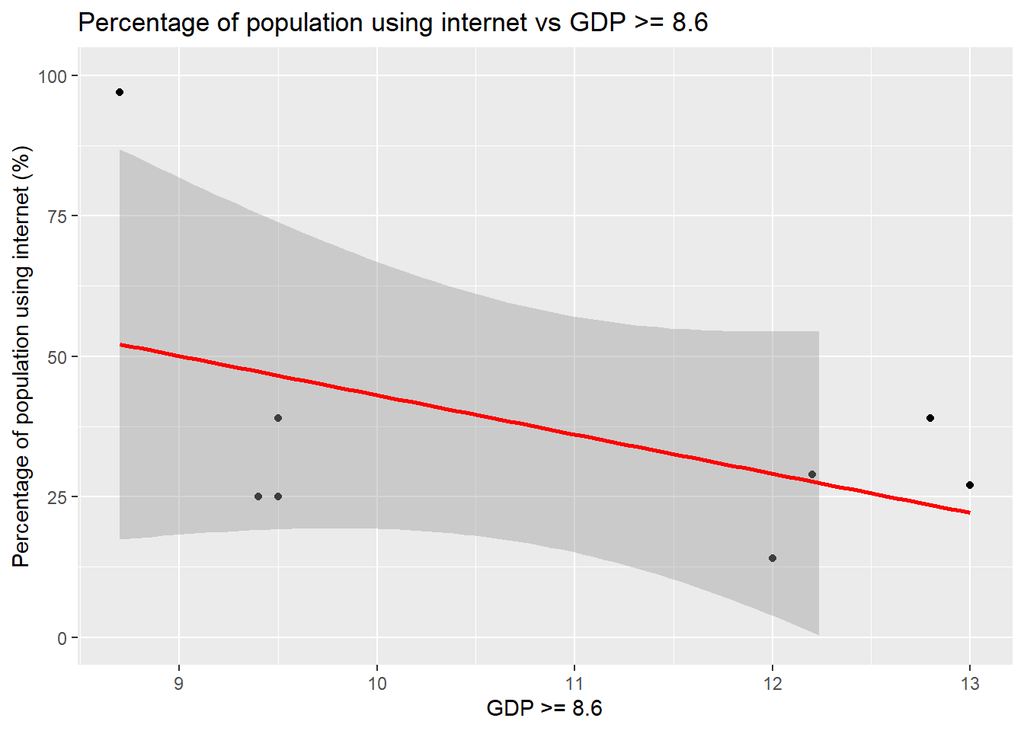

```r
education_gdp_3 <- expenditure_percentage %>%
  filter(group == '3') %>%
  select (`(% OF GDP).x`, group, percentage)
ggplot(data = education_gdp_3, aes(x = `(% OF GDP).x`, y = percentage)) + geom_point() + stat_smooth(method = "lm", colour = "Red") + ylim(0,100) + xlab("GDP >= 8.6") + ylab("Percentage of population using internet (%)") + labs(title = "Percentage of population using internet vs GDP >= 8.6")
```

Create a boxplot by linking different groups of democracy scores to percentage.

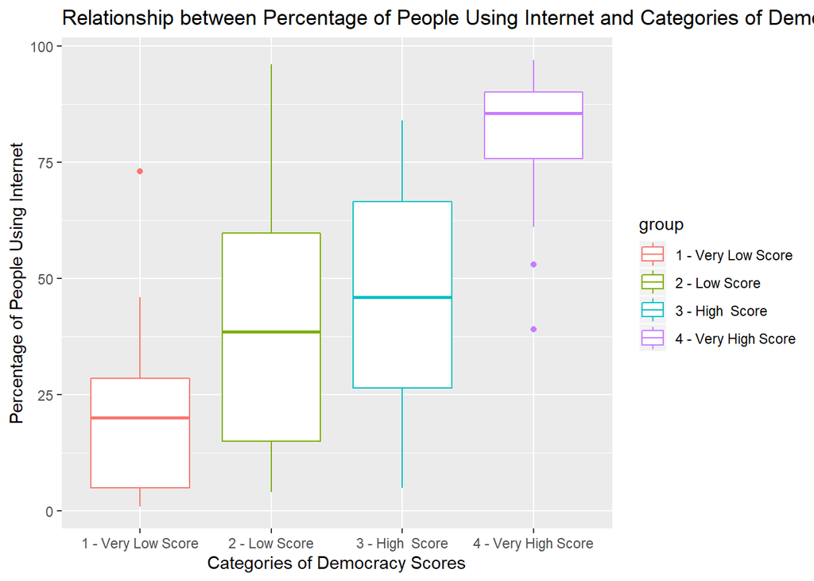

```r
democracy_percentage <- inner_join(democracyindex2017, internet_population, by = "Country")
democracy_percentage <- democracy_percentage %>%
  mutate (`Democracy Score` = parse_number(Score))

democracy_percentage <- democracy_percentage %>%
  mutate(group = ifelse(`Democracy Score` < 2.5, '1 - Very Low Score',ifelse(`Democracy Score` >= 2.5 & `Democracy Score` < 5, '2 - Low Score', ifelse(`Democracy Score` >= 5 & `Democracy Score` < 7.5, '3 - High  Score', '4 - Very High Score'))))

democracy_percentage <- democracy_percentage %>%
  group_by(group) %>%
  select (`Democracy Score`, Country, group)

# Combine democracy_percentage with internet_population and create a box plot
democracy_whisker <- inner_join(democracy_percentage, internet_population, by = "Country")

ggplot(data = democracy_whisker, aes(x = group, y = percentage, color = group)) + geom_boxplot() + labs(x = "Categories of Democracy Scores", y = "Percentage of People Using Internet", title = "Relationship between Percentage of People Using Internet and Categories of Democracy Scores")
```

GEOGRAPHICAL MAPPING OF INTERNET USAGE

[figure not shown]

```r
globe <- map_data("world")

#internetusers_cia2017 <- read_csv("internetusers_cia2017.csv")

in_per <- internet_population %>% rename(region = Country)

in_per$region[4] <- "USA" # to match world map data

in_per <- semi_join(in_per, globe, by = "region") #only keep countries according to world map data

# code below is modified from
# https://stackoverflow.com/questions/29614972/ggplot-us-state-map-colors-are-fine-polygons-jagged-r
gg <- ggplot()

gg <- gg + geom_map(
  data = globe,
  map = globe,
  aes(x = long, y = lat, map_id = region),
  fill = "#ffffff",
  color = "#ffffff",
  size = 0.20
  )
  gg <- gg + geom_map(
  data = in_per,
  map = globe,
  aes(fill = percentage, map_id = region),
  color = "#ffffff",
  size = 0.15
  )

  gg <- gg + scale_fill_continuous(low = 'lightgreen', high = 'darkgreen',
  guide = 'colorbar') + labs(x = "Latitude", y = "Longitude", title = "Worldwide geographical representation of Internet Usage")
  gg
```

Percentile bootstrap method on percentage of internet users Note: 500 Replciations have been used instead of 5000 to reduce run time

```r
PER <- internet_population %>% filter(is.na(percentage) == FALSE & percentage<= 100)

# Take a 25% sample of the original data
sample25 <- PER %>% sample_n(size = 25)

sample_means <- rep(NA, 500)
for (i in 1:500){
  sample25 <- PER %>% sample_n(size = 25)
  sample_means[i] <- as.numeric(sample25 %>%
                                  summarize(mean(percentage)))
}
sample_means <- data_frame(mean_percentage = sample_means)
```

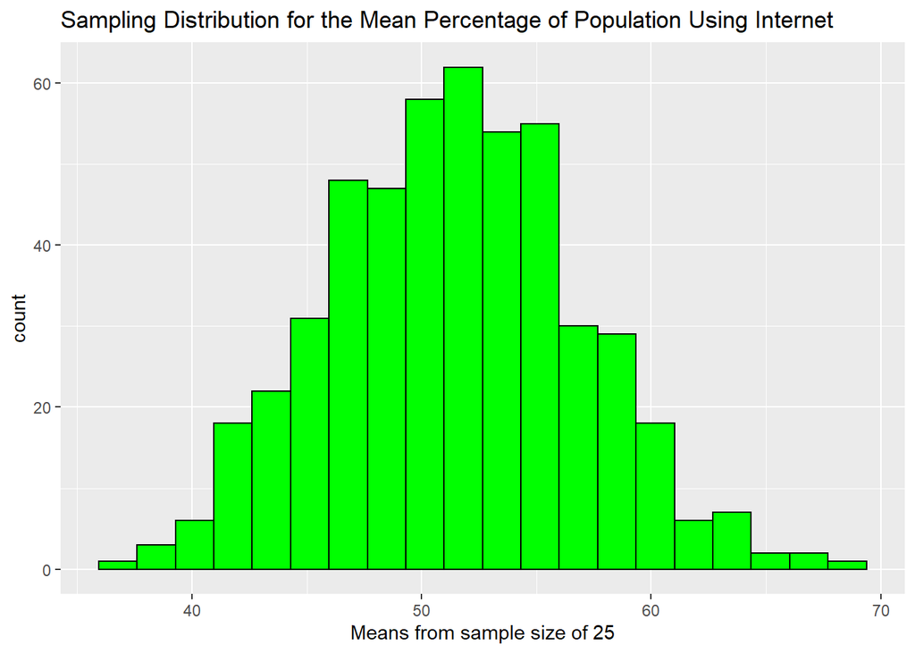

```r
ggplot(data = sample_means, aes(x = mean_percentage)) + geom_histogram(bins= 20, colour = "Black", fill = "Green") + labs(x = "Means from sample size of 25", title = "Sampling Distribution for the Mean Percentage of Population Using Internet")
```

```r
observed_data <- PER %>% sample_n(size = 200, replace = FALSE)
observed_mean <- as.numeric(observed_data %>%
                              summarize (mean(percentage)))

boot_samp <- observed_data %>% sample_n(size = 200, replace = TRUE)
boot_samp %>% summarize(mean_percentage = mean(percentage))
```

```
## # A tibble: 1 x 1
##   mean_percentage
##             <dbl>
## 1            48.7
```

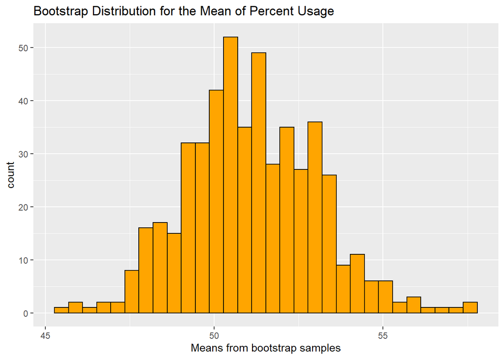

```r
boot_means <- rep(NA, 500)
for (i in 1:500){
  boot_samp <- observed_data %>% sample_n(size = 200, replace = TRUE)
  boot_means[i] <- as.numeric(boot_samp %>%
                                summarize(mean_percentage = mean(percentage)))
}
boot_means <- data_frame(mean_percentage = boot_means)

ggplot(boot_means, aes(x = mean_percentage)) + geom_histogram(bins = 30, colour = "Black", fill = "Orange") + labs(x = "Means from bootstrap samples", title = "Bootstrap Distribution for the Mean of Percent Usage")
```

```r
population_mean <- PER %>%
  summarize(population_mean_percentage = mean(percentage))
population_mean
```

```
## # A tibble: 1 x 1
##   population_mean_percentage
##                        <dbl>
## 1                       51.3
```

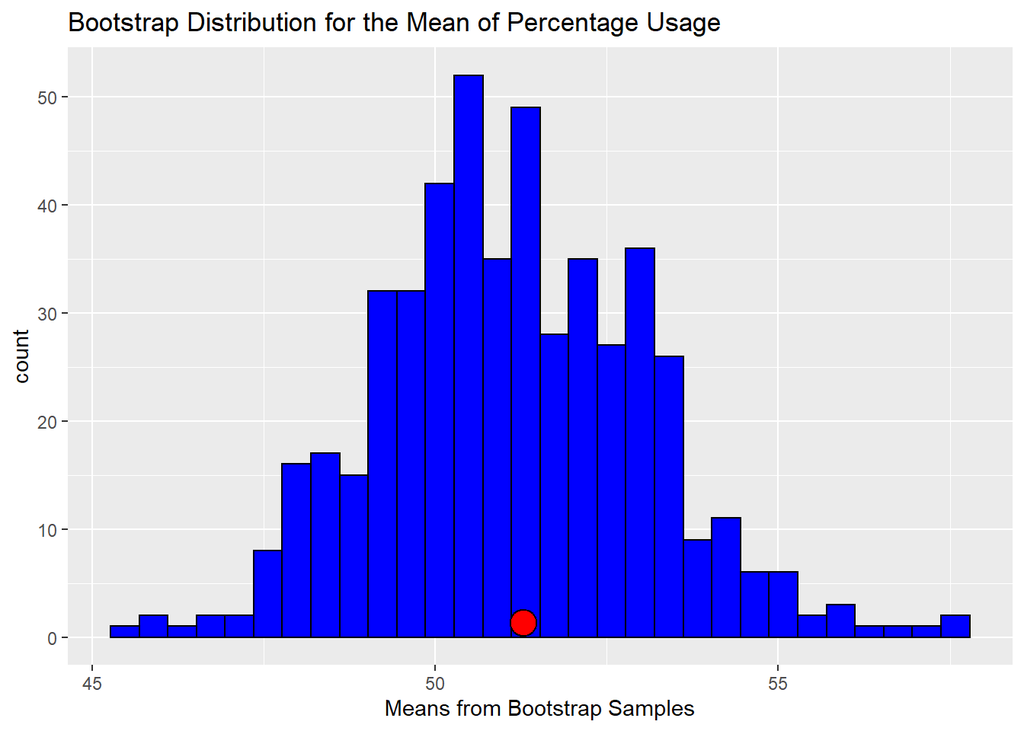

```r
ggplot(boot_means, aes(x = mean_percentage)) + geom_histogram(bins = 30, colour = "Black", fill = "Blue") + geom_dotplot(data = population_mean, aes(x = population_mean_percentage), fill = "Red") + labs(x = "Means from Bootstrap Samples", title = "Bootstrap Distribution for the Mean of Percentage Usage")
```

```r
# Generate 100 bootstrap samples
n_interval <- 100
perc_25 <- rep(NA, n_interval)
perc_975 <- rep(NA, n_interval)
sample_size <- 200
replications <- 500
for (i in 1:n_interval){
  observed_data <- PER %>%
    sample_n(size = sample_size, replace = FALSE)

  boot_means <- rep(NA, replications)
  for (j in 1:replications){
    boot_samp <- observed_data %>%
      sample_n(size = sample_size, replace = TRUE)
    boot_means[j] <- as.numeric(boot_samp %>%
                                  summarize(mean(percentage)))
  }

  perc_25[i] <- quantile(boot_means, 0.025)
  perc_975[i] <- quantile(boot_means, 0.975)

  print(c(i, perc_25[i], perc_975[i]))
}
```

```
## [1]  1.00000 47.32475 55.18175
## [1]  2.00000 47.04738 54.54050
## [1]  3.00000 47.42925 55.37575
## [1]  4.00000 47.04188 54.99788
## [1]  5.00000 48.02350 55.64538
## [1]  6.0000 46.0575 53.7810
## [1]  7.00000 47.39300 55.11312
## [1]  8.00000 48.58975 56.39600
## [1]  9.00000 46.13112 54.32887
## [1] 10.00000 48.10963 55.85675
## [1] 11.00000 48.66237 55.86650
## [1] 12.00000 48.24713 55.49712
## [1] 13.00000 47.93063 55.73887
## [1] 14.00000 47.33888 55.02587
## [1] 15.00000 46.18250 53.94288
```

[output cut: 85 more lines]

Relationship between life expectency and percentage

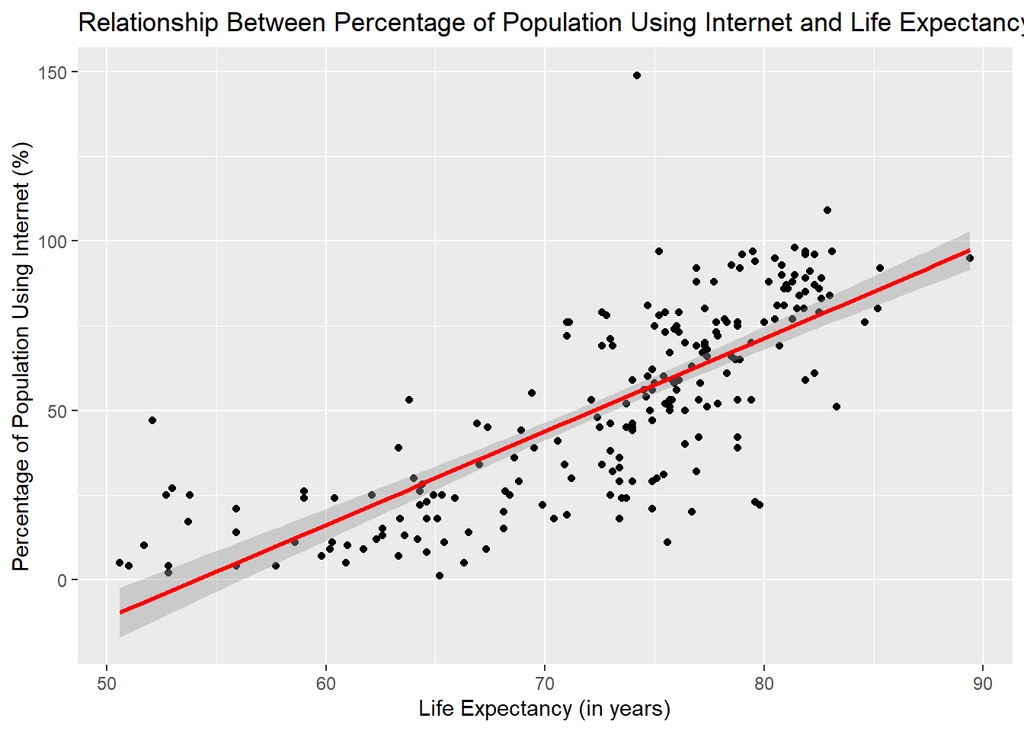

```r
life_percent <- inner_join(lifeexpect_cia2017, internet_population, by = "Country")

ggplot(data = life_percent, aes(x = `(YEARS)`, y = percentage)) + geom_point() + stat_smooth(method = "lm", colour = "Red", se = TRUE) + labs(x = "Life Expectancy (in years)", y = "Percentage of Population Using Internet (%)", title = "Relationship Between Percentage of Population Using Internet and Life Expectancy")
```

CLASSIFICATION TREE ON LIFE EXPECTENCY AND HEALTH EXPENDITURE

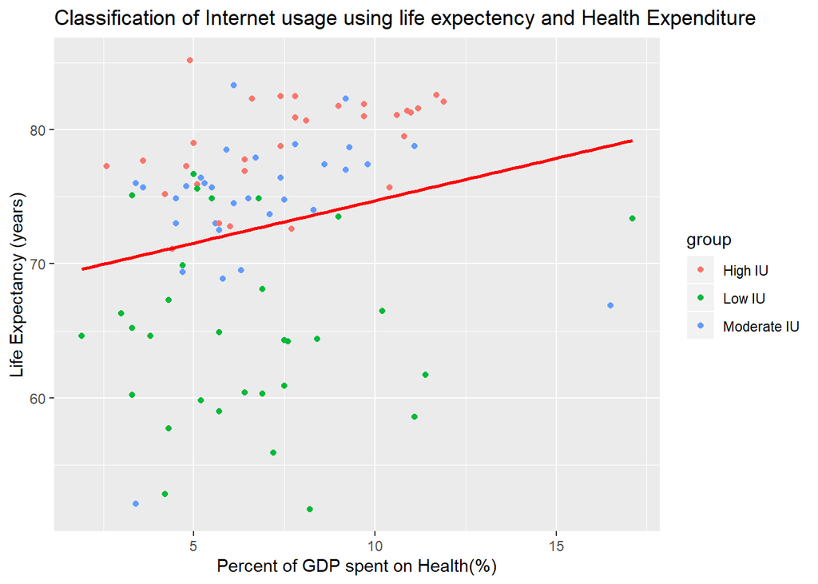

```r
set.seed(2150)
tree_df <- inner_join(lifeexpect_cia2017, healthexpend_cia2017, by = "Country")
tree_df <- inner_join(tree_df, internet_population, by = "Country")

tree_df$`Date of Information.x` <- NULL
tree_df$`Date of Information.y` <- NULL
tree_df <- tree_df %>%
  rename(years = `(YEARS)`, gdp = `(% OF GDP)`) %>%
  mutate(group = ifelse(percentage <=33, 'Low IU',ifelse(percentage > 33 & percentage <= 66, "Moderate IU", "High IU")))

tree_df <- tree_df %>% sample_n(size = 92)


ggplot(data = tree_df, aes(x = gdp, y = years, colour = group)) + geom_point() + stat_smooth(method = "lm", colour = "Red", se = FALSE) + labs(x = "Percent of GDP spent on Health(%)", y = "Life Expectancy (years)", title = "Classification of Internet usage using life expectency and Health Expenditure")
```

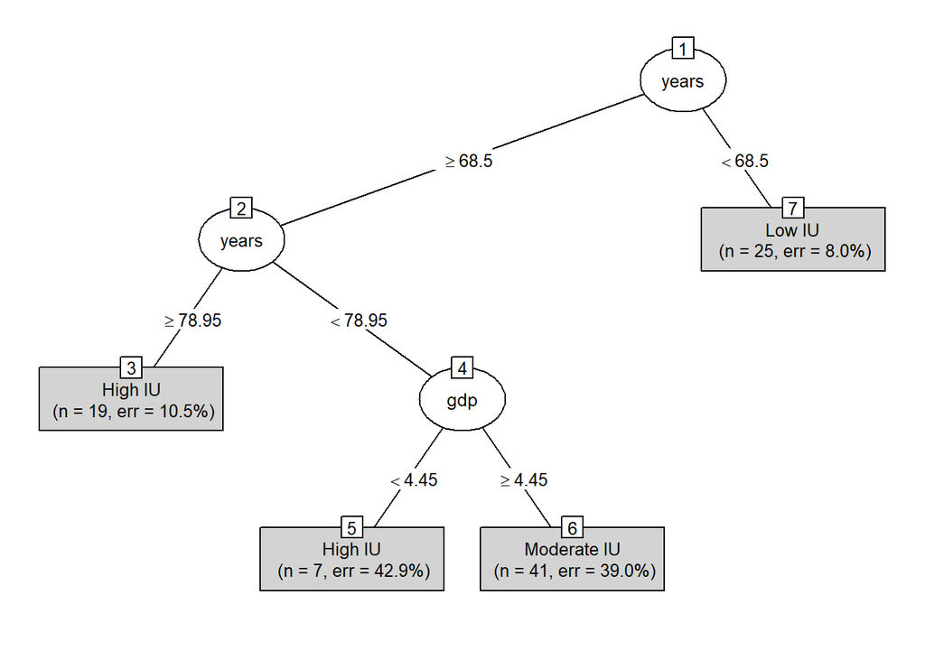

```r
# Create a classification tree
tree <- rpart(group ~ gdp + years, data = tree_df)
plot(as.party(tree), type = "simple", gp = gpar(cex = 0.8))
```

Relationship between telephone lines and percentage

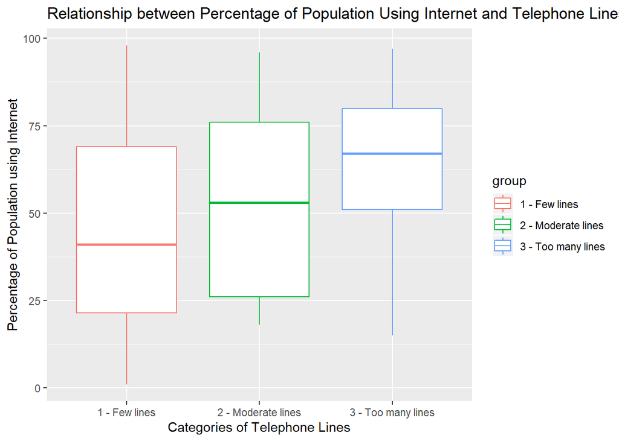

```r
tele_percentage <- inner_join(telephonelines_cia2017, internet_population, by="Country")
tele_percentage <- tele_percentage %>%
  rename(lines = `TELEPHONES - MAIN LINES IN USE`)

#ggplot(data = tele_percentage, aes(x = lines, y = percentage)) + geom_point() + stat_smooth(method = #"lm", colour = "Red", se = TRUE) + xlim(0,1500000) + ylim(0,100)

tele_percentage <- tele_percentage %>%
  mutate(group = ifelse(lines <= 500000, "1 - Few lines", ifelse(lines > 500000 & lines <= 1000000, "2 - Moderate lines", "3 - Too many lines"))) %>%
  filter (percentage <= 100) %>%
  select(percentage, group, lines)

ggplot(data = tele_percentage, aes(x = group, y = percentage, color = group)) + geom_boxplot() + labs(x = "Categories of Telephone Lines", y = "Percentage of Population using Internet", title = "Relationship between Percentage of Population Using Internet and Telephone Lines")
```

Link to all datasets on World Factbook: https://www.cia.gov/library/publications/resources/the-world-factbook/rankorder/rankorderguide.html

Link to definitions of words from Dataset: https://www.cia.gov/library/publications/resources/the-world-factbook/docs/notesanddefs.html

- Data Wrangling (included)
- Exploratory data analysis (included)
- Plot and summary statistics (included)
- Confidence Intervals (included)
- Classification trees (included)
- Regression models(included)